# 1) DataFrame Analysis:-

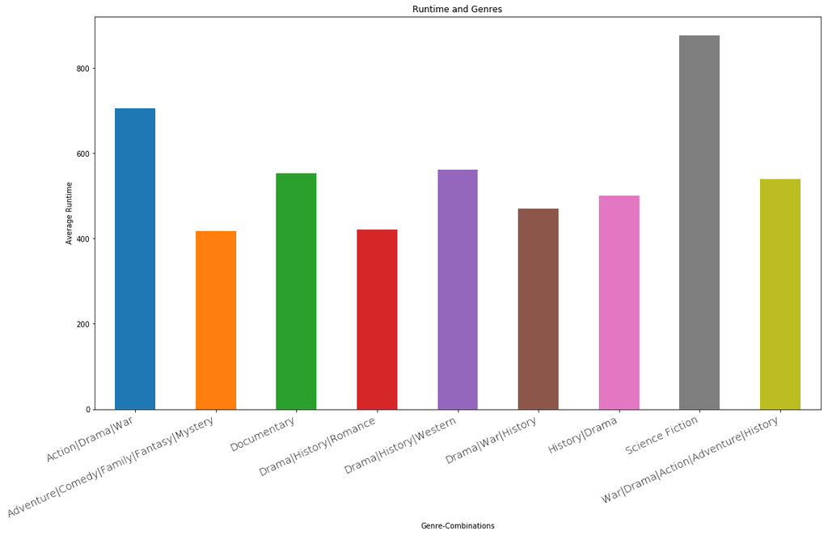

```python
df[df['runtime']>= 400].groupby(['genres'])['runtime'].mean().plot(kind='bar')
plt.xlabel('Genre-Combinations')
plt.ylabel('Average Runtime')
plt.title('Runtime and Genres');
plt.xticks(
    rotation=25,
    horizontalalignment='right',
    fontweight='light',
    fontsize='x-large'
);
```

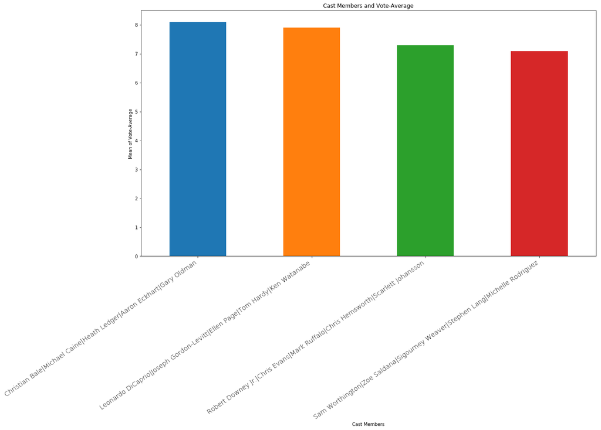

```python
#df['vote_average'].describe()
#df['vote_count'].describe()
df[df['vote_count']> 8000].groupby(['cast'])['vote_average'].mean().plot(kind='bar')
plt.xlabel('Cast Members')
plt.ylabel('Mean of Vote-Average')
plt.title('Cast Members and Vote-Average');
plt.xticks(
    rotation=35,
    horizontalalignment='right',
    fontweight='light',
    fontsize='x-large'
)
```

- #### Looks like Cast members contribute to a better vote-average

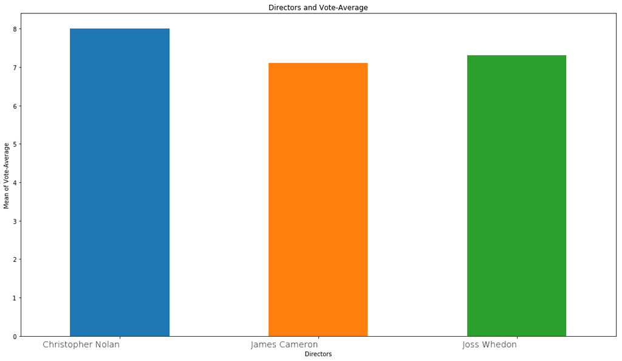

```python
df[df['vote_count']> 8000].groupby(['director'])['vote_average'].mean().plot(kind='bar')
plt.xlabel('Directors')
plt.ylabel('Mean of Vote-Average')
plt.title('Directors and Vote-Average');
plt.xticks(
    rotation=0,
    horizontalalignment='right',
    fontweight='light',
    fontsize='x-large'
);
```

- #### Directors like (Christopher Nolan, Joss Whedon, James Cameron) are assosiated and correlated with better Vote-Average
- ### Q.12 (What affects `Revenue_adj`?)

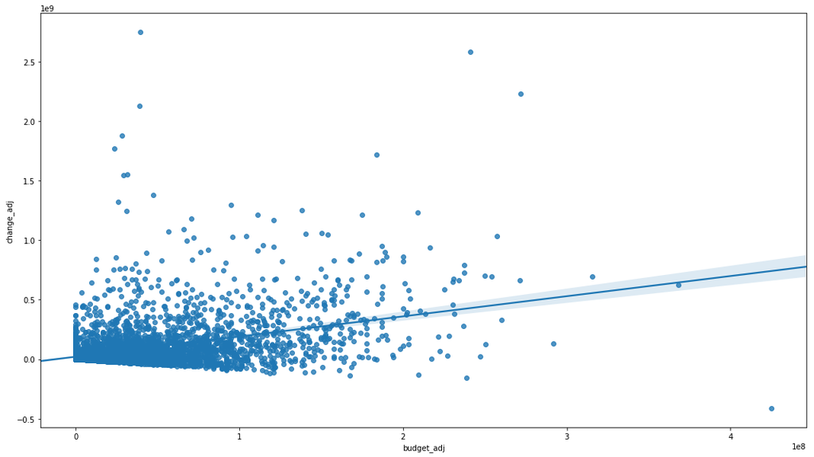

```python
dff= df[df['revenue_adj']>0]                               #Excluded revenue with nill values for better visualisation
x= dff.groupby(['id']).median().budget_adj
y= dff.groupby(['id']).median().change_adj
sns.regplot(x, y);
```

- #### There is no defined correlation, but it seems that budgets from 1.7 to 2 are the best choices if the movie fails

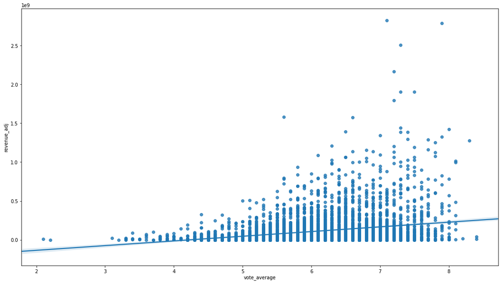

```python
x= dff.groupby(['id']).median().vote_average
y= dff.groupby(['id']).median().revenue_adj
sns.regplot(x, y);
```

- #### Again, there is no strong defined correlation, but it seems that the more the average-vote the more likely the revenue is high

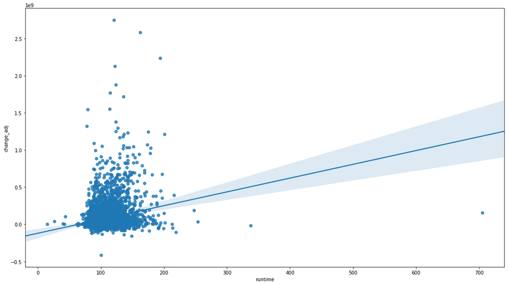

```python
x= dff.groupby(['id']).median().runtime
y= dff.groupby(['id']).median().change_adj
sns.regplot(x, y);
```

- #### Looks like the regression line show that the more runtime the more the revenue, but to be safe a 100 to 200 would be a good choice due to its affect on average-vote

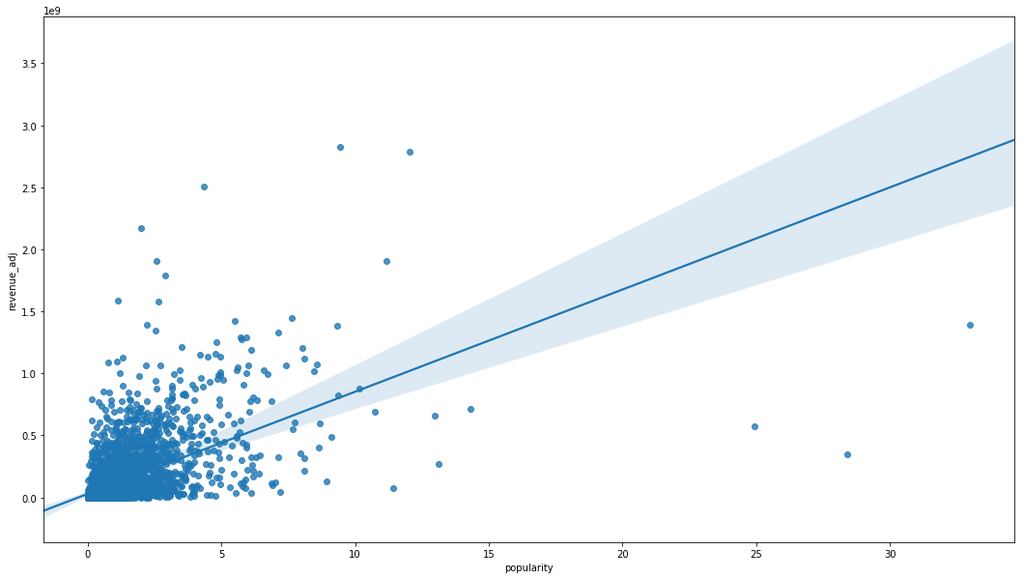

```python
x= dff.groupby(['id']).median().popularity
y= dff.groupby(['id']).median().revenue_adj
sns.regplot(x, y);
```

```
Text(0.5,1,'Frequency of Income')
```

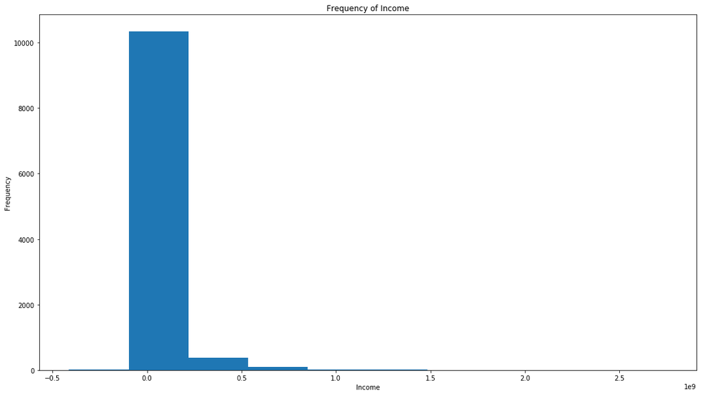

```python
df['change_adj'].plot(kind='hist');
plt.xlabel('Income')
plt.title('Frequency of Income')
```

- #### Looks like the chance of failiure is low, yet it is probable.
- ### Q.14 (What is the range of budget that may be spent in a movie?)

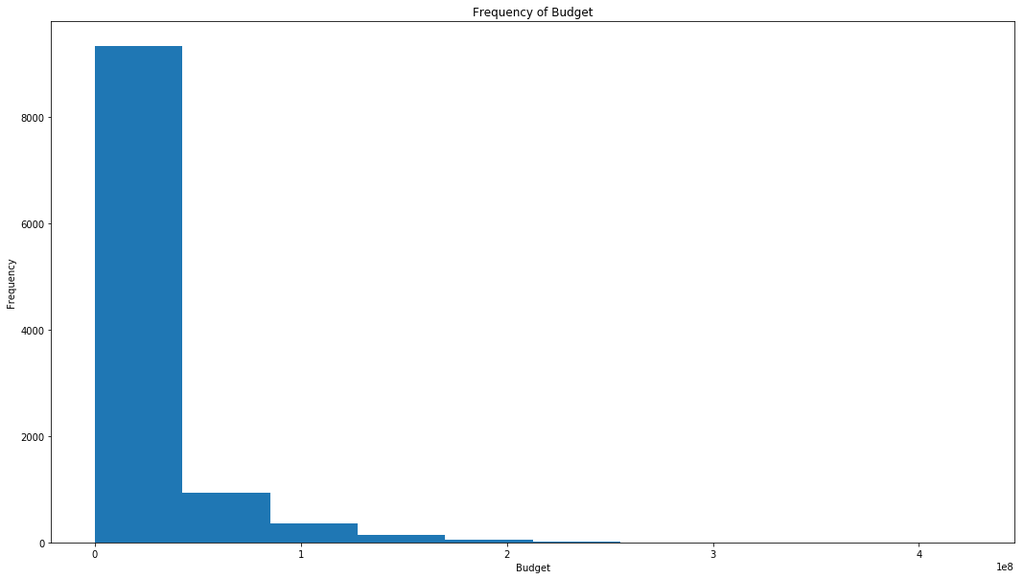

```python
df['budget_adj'].plot(kind='hist');
plt.xlabel('Budget')
plt.title('Frequency of Budget');
```

- #### Looks like from 0 to 0.4 is what a movie might take

## Conclusions

### Limitations

```
- There was no solid correlation between Runtime & Income. (Q.12)
- There was no strong correlation between Budget & Revenue. (Q.12)
- Vote-Averages seem to be declining with time, so contribution to a better Vote-Average would increase the chances of         revenue as they correlate positively. (Q.9)
```

- #### Sources that helped me
  - https://stackoverflow.com/questions/8023306/get-key-by-value-in-dictionary
  - https://stackoverflow.com/questions/36367986/how-to-make-inline-plots-in-jupyter-notebook-larger
  - https://stackoverflow.com/questions/54883814/using-group-by-in-regression-to-define-x-and-y-values-in-python

```python
#from subprocess import call
#call(['python', '-m', 'nbconvert', 'Investigate_a_Dataset.ipynb'])
```